# Final Project

Author

Liam Dickson

```r
library(tidyverse)
library(ggplot2)
library(stargazer)
basics <- read_tsv("title.basics.tsv.gz", na = "\\N")
ratings <- read_tsv("title.ratings.tsv.gz", na = "\\N")
episodes <- read_tsv("title.episode.tsv.gz", na = "\\N")
episode_counts <- episodes %>%
  group_by(parentTconst) %>%
  summarise(
    num_episodes = n(),
    num_seasons = n_distinct(seasonNumber, na.rm = TRUE),
    .groups = "drop"
  )

tv_data <- basics %>%
  filter(titleType == "tvSeries") %>%
  left_join(ratings, by = "tconst") %>%
  left_join(episode_counts, by = c("tconst" = "parentTconst")) %>%
  select(
    tconst,
    primaryTitle,
    startYear,
    runtimeMinutes,
    genres,
    averageRating,
    numVotes,
    num_episodes,
    num_seasons
  ) %>%
  mutate(
    startYear = as.numeric(startYear),
    runtimeMinutes = as.numeric(runtimeMinutes),
    averageRating = as.numeric(averageRating),
    numVotes = as.numeric(numVotes)
  ) %>%
  filter(
    !is.na(runtimeMinutes),
    !is.na(averageRating),
    !is.na(startYear),
    startYear > 1950
  )

tv_data <- tv_data %>%
  mutate(
    show_age = 2025 - startYear,
    log_votes = log(numVotes),
    main_genre = word(genres, 1, sep = ",")
  )

glimpse(tv_data)
```

```
Rows: 58,167
Columns: 12
$ tconst         <chr> "tt0041024", "tt0041030", "tt0042114", "tt0042150", "tt…
$ primaryTitle   <chr> "The Ford Television Theatre", "Hopalong Cassidy", "The…
$ startYear      <dbl> 1952, 1952, 1955, 1952, 1951, 1951, 1951, 1951, 1951, 1…
$ runtimeMinutes <dbl> 30, 60, 30, 60, 30, 30, 30, 30, 30, 60, 15, 30, 60, 60,…
$ genres         <chr> "Drama", "Western", "Comedy,Family", "Comedy", "Comedy,…
$ averageRating  <dbl> 7.3, 7.6, 8.6, 7.4, 5.9, 6.9, 7.6, 4.6, 8.7, 6.4, 8.1, …
$ numVotes       <dbl> 291, 440, 6806, 39, 17, 147, 255, 10, 912, 19, 48, 160,…
$ num_episodes   <int> 195, 52, 39, 6, 5, 105, 113, 3, 78, 67, 8, 58, 20, 13, …
$ num_seasons    <int> 5, 2, 1, 1, 1, 4, 8, 0, 4, 0, 2, 2, 1, 1, 2, 1, 7, 8, 1…
$ show_age       <dbl> 73, 73, 70, 73, 74, 74, 74, 74, 74, 74, 74, 74, 74, 74,…
$ log_votes      <dbl> 5.673323, 6.086775, 8.825560, 3.663562, 2.833213, 4.990…
$ main_genre     <chr> "Drama", "Western", "Comedy", "Comedy", "Comedy", "West…
```

```r
summary(tv_data)
```

```
    tconst          primaryTitle         startYear    runtimeMinutes
 Length:58167       Length:58167       Min.   :1951   Min.   :      1
 Class :character   Class :character   1st Qu.:1999   1st Qu.:     25
 Mode  :character   Mode  :character   Median :2010   Median :     40
                                       Mean   :2006   Mean   :    113
                                       3rd Qu.:2018   3rd Qu.:     60
                                       Max.   :2026   Max.   :3692080

    genres          averageRating      numVotes        num_episodes
 Length:58167       Min.   :1.000   Min.   :      5   Min.   :    1.00
 Class :character   1st Qu.:6.100   1st Qu.:     19   1st Qu.:    8.00
 Mode  :character   Median :7.000   Median :     58   Median :   18.00
                    Mean   :6.798   Mean   :   2832   Mean   :   81.87
                    3rd Qu.:7.700   3rd Qu.:    315   3rd Qu.:   49.00
                    Max.   :9.800   Max.   :2588585   Max.   :15355.00
                                                      NA's   :4150
  num_seasons       show_age       log_votes       main_genre
 Min.   :  0.0   Min.   :-1.00   Min.   : 1.609   Length:58167
 1st Qu.:  1.0   1st Qu.: 7.00   1st Qu.: 2.944   Class :character
 Median :  1.0   Median :15.00   Median : 4.060   Mode  :character
 Mean   :  2.4   Mean   :19.07   Mean   : 4.584
 3rd Qu.:  2.0   3rd Qu.:26.00   3rd Qu.: 5.753
 Max.   :263.0   Max.   :74.00   Max.   :14.767
 NA's   :4150
```

```r
tv_data %>%
  summarise(
    mean_rating = mean(averageRating, na.rm = TRUE),
    median_rating = median(averageRating, na.rm = TRUE),
    mean_runtime = mean(runtimeMinutes, na.rm = TRUE),
    mean_votes = mean(numVotes, na.rm = TRUE),
    mean_episodes = mean(num_episodes, na.rm = TRUE),
    mean_seasons = mean(num_seasons, na.rm = TRUE)
  )
```

```
# A tibble: 1 × 6
  mean_rating median_rating mean_runtime mean_votes mean_episodes mean_seasons
        <dbl>         <dbl>        <dbl>      <dbl>         <dbl>        <dbl>
1        6.80             7         113.      2832.          81.9         2.40
```

# Final Project

## Research Question

What characteristics of television shows such as run-time, release year, and popularity are associated with higher IMDb ratings?

## Motivation for Research Questions

I aspire to work in a film or entertainment industry in my future, this research serves as both a personal interest and a chance to further my statistical data analysis skills. I think TV shows are a relatively universal topic too, so having consumption from both a large amount of people and a large amount of viewers is also very intriguing. The research questions themselves come from thoughts of change over time in TV and just general curiosity as to what makes a “good” TV show. There are no clear answers to this question, but there are different perspectives to look at and take to dig deeper.

## Hypotheses

1. Shows with longer run-times will have higher ratings. - 2. More recent television shows will have higher ratings due to improvements in production quality and learning from previous TV shows. - 3. TV shows with more IMDb votes will have higher average ratings.

## Motivation for Hypotheses

These hypotheses are relatively general, but hope is to combine them to take a one personal perspective on what potential findings could add to film industry. The findings while mostly based on personal curiosity, can add both a young and new perspective combined with statistical research as to what aspects of TV shows can be more appealing and stand out both now, by genre, and over time.

## Key Statistics/Variables

While the data set I have made is combined from IMBD ratings and different publicly accessible data sets from IMBD - I will mostly focus on year, genre, and rating for my research. I made incorporate other elements perhaps based more on visualization and color, but these are the thoughts I have currently.To improve the analysis, episode-level data were incorporated to add additional variables including the number of seasons and number of episodes for each television show. These variables serve as indicators for production scale and show longevity. The final data set includes thousands of television shows and multiple variables.

## Variables Cont

The response variable in this analysis is the average IMDb rating of a television show. The main explanatory variables are run-time, release year, and number of IMDb votes, which are used to test the hypotheses about episode length, rage of the show, and popularity. Control variables include the number of episodes and number of seasons, which help account for production scale and show longevity.

## Transformation Variables

The number of IMDb votes is highly right-skewed, so a logarithmic transformation is used. This reduces the influence of extremely popular shows and improves interpretability and model stability.

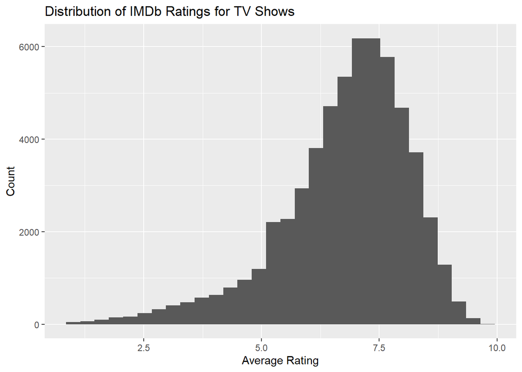

```r
ggplot(tv_data, aes(x = averageRating)) +
  geom_histogram(bins = 30) +
  labs(
    title = "Distribution of IMDb Ratings for TV Shows",
    x = "Average Rating",
    y = "Count"
  )
```

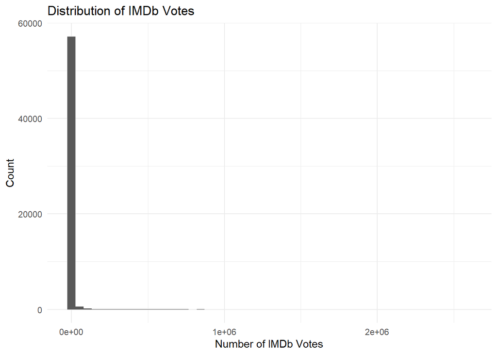

```r
ggplot(tv_data, aes(x = numVotes)) +
  geom_histogram(bins = 50) +
  labs(
    title = "Distribution of IMDb Votes",
    x = "Number of IMDb Votes",
    y = "Count"
  ) +
  theme_minimal()
```

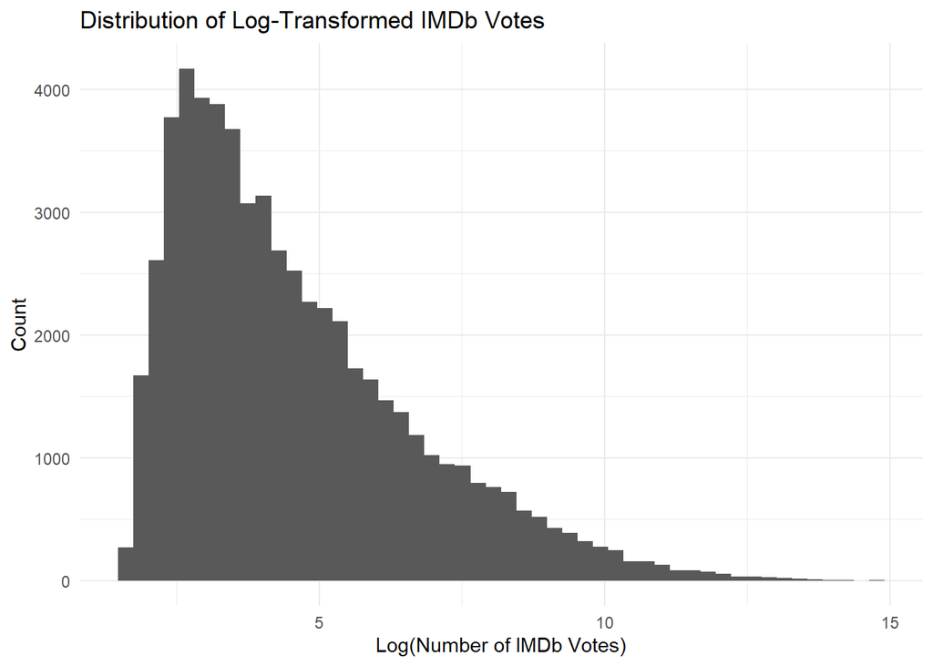

```r
ggplot(tv_data, aes(x = log_votes)) +
  geom_histogram(bins = 50) +
  labs(
    title = "Distribution of Log-Transformed IMDb Votes",
    x = "Log(Number of IMDb Votes)",
    y = "Count"
  ) +
  theme_minimal()
```

[figure not shown]

```r
tv_data <- tv_data %>%
  mutate(main_genre = word(genres, 1, sep = ","))

top_genres <- tv_data %>%
  count(main_genre, sort = TRUE) %>%
  slice_head(n = 10)

tv_data %>%
  filter(main_genre %in% top_genres$main_genre) %>%
  ggplot(aes(x = main_genre, y = averageRating)) +
  geom_boxplot() +
  labs(
    title = "IMDb Ratings by TV Show Genre",
    x = "Genre",
    y = "Average Rating"
  )
```

[figure not shown]

```r
tv_data <- tv_data %>%
  mutate(
    startYear = as.numeric(startYear),
    averageRating = as.numeric(averageRating)
  ) %>%
  filter(!is.na(startYear), !is.na(averageRating))

ratings_by_year <- tv_data %>%
  group_by(startYear) %>%
  summarise(mean_rating = mean(averageRating), n = n(), .groups = "drop") %>%
  filter(n >= 5)

top_genres <- tv_data %>%
  count(main_genre, sort = TRUE) %>%
  slice_head(n = 10)

tv_data %>%
  filter(main_genre %in% top_genres$main_genre) %>%
  ggplot(aes(x = reorder(main_genre, averageRating, median),
             y = averageRating)) +
  geom_boxplot(outlier.alpha = 0.15) +
  coord_flip() +
  labs(
    title = "IMDb Ratings by Genre",
    x = "Genre",
    y = "Average IMDb Rating"
  ) +
  theme_minimal()
```

# Graph Analysis

The distribution of IMDb votes is highly right-skewed. Most TV shows receive relatively small numbers of votes, while a small number of highly popular shows receive extremely large numbers of votes. This graph indicates the presence of substantial outliers and unequal popularity across TV series.

After applying a logarithmic transformation, the distribution of IMDb votes becomes substantially less skewed and more evenly distributed. This transformation reduces the influence of extremely popular shows and makes the variable more appropriate for regression analysis.

The genre comparison highlights differences in audience engagement and enjoyment across television categories. Documentary, adventure, and family-oriented shows generally exhibit higher median ratings, while reality television and game shows tend to have lower median ratings and greater variability. This suggests that audience preferences differ across genres.

# Models and Diagnostics

```r
tv_model <- tv_data %>%
  select(
    averageRating,
    runtimeMinutes,
    show_age,
    log_votes,
    num_episodes,
    num_seasons
  ) %>%
  drop_na()

m1 <- lm(averageRating ~ runtimeMinutes, data = tv_model)
summary(m1)
```

```
Call:
lm(formula = averageRating ~ runtimeMinutes, data = tv_model)

Residuals:
    Min      1Q  Median      3Q     Max
-5.8188 -0.6186  0.1814  0.8814  2.9814

Coefficients:
                Estimate Std. Error  t value Pr(>|t|)
(Intercept)    6.819e+00  5.746e-03 1186.718   <2e-16 ***
runtimeMinutes 2.868e-07  3.617e-07    0.793    0.428
---
Signif. codes:  0 '***' 0.001 '**' 0.01 '*' 0.05 '.' 0.1 ' ' 1

Residual standard error: 1.335 on 54015 degrees of freedom
Multiple R-squared:  1.164e-05, Adjusted R-squared:  -6.875e-06
F-statistic: 0.6287 on 1 and 54015 DF,  p-value: 0.4278
```

```r
m2 <- lm(averageRating ~ runtimeMinutes + show_age + log_votes, data = tv_model)
summary(m2)
```

```
Call:
lm(formula = averageRating ~ runtimeMinutes + show_age + log_votes,
    data = tv_model)

Residuals:
    Min      1Q  Median      3Q     Max
-6.0035 -0.6411  0.1921  0.8957  3.2735

Coefficients:
                Estimate Std. Error t value Pr(>|t|)
(Intercept)    6.382e+00  1.608e-02  396.91   <2e-16 ***
runtimeMinutes 2.833e-07  3.589e-07    0.79     0.43
show_age       4.556e-03  3.539e-04   12.88   <2e-16 ***
log_votes      7.420e-02  2.706e-03   27.42   <2e-16 ***
---
Signif. codes:  0 '***' 0.001 '**' 0.01 '*' 0.05 '.' 0.1 ' ' 1

Residual standard error: 1.325 on 54013 degrees of freedom
Multiple R-squared:  0.01555,   Adjusted R-squared:  0.0155
F-statistic: 284.5 on 3 and 54013 DF,  p-value: < 2.2e-16
```

```r
m3 <- lm(averageRating ~ runtimeMinutes + show_age + log_votes +
           num_episodes + num_seasons, data = tv_model)
summary(m3)
```

```
Call:
lm(formula = averageRating ~ runtimeMinutes + show_age + log_votes +
    num_episodes + num_seasons, data = tv_model)

Residuals:
    Min      1Q  Median      3Q     Max
-6.0237 -0.6459  0.1831  0.8865  5.0702

Coefficients:
                 Estimate Std. Error t value Pr(>|t|)
(Intercept)     6.367e+00  1.600e-02 398.055  < 2e-16 ***
runtimeMinutes  2.799e-07  3.567e-07   0.785    0.433
show_age        5.264e-03  3.548e-04  14.837  < 2e-16 ***
log_votes       7.663e-02  2.748e-03  27.887  < 2e-16 ***
num_episodes   -4.067e-04  1.592e-05 -25.551  < 2e-16 ***
num_seasons     9.826e-03  1.494e-03   6.575 4.89e-11 ***
---
Signif. codes:  0 '***' 0.001 '**' 0.01 '*' 0.05 '.' 0.1 ' ' 1

Residual standard error: 1.317 on 54011 degrees of freedom
Multiple R-squared:  0.02731,   Adjusted R-squared:  0.02722
F-statistic: 303.3 on 5 and 54011 DF,  p-value: < 2.2e-16
```

```r
stargazer(
  m1, m2, m3,
  type = "text",
  digits = 6,
  title = "Regression Results Predicting IMDb Ratings",
  dep.var.labels = "Average IMDb Rating",
  covariate.labels = c(
    "Runtime",
    "Show Age",
    "Log IMDb Votes",
    "Number of Episodes",
    "Number of Seasons"
  ),
  omit.stat = c("f", "ser"),
  no.space = TRUE
)
```

```
Regression Results Predicting IMDb Ratings
=======================================================
                           Dependent variable:
                   ------------------------------------
                           Average IMDb Rating
                       (1)         (2)         (3)
-------------------------------------------------------
Runtime             0.0000003   0.0000003   0.0000003
                   (0.0000004) (0.0000004) (0.0000004)
Show Age                       0.004556*** 0.005264***
                               (0.000354)   (0.000355)
Log IMDb Votes                 0.074204*** 0.076628***
                               (0.002706)   (0.002748)
Number of Episodes                         -0.000407***
                                            (0.000016)
Number of Seasons                          0.009826***
                                            (0.001494)
Constant           6.818548*** 6.382144*** 6.366986***
                   (0.005746)  (0.016080)   (0.015995)
-------------------------------------------------------
Observations         54,017      54,017       54,017
R2                  0.000012    0.015554     0.027311
Adjusted R2         -0.000007   0.015499     0.027221
=======================================================
Note:                       *p<0.1; **p<0.05; ***p<0.01
```

```r
AIC(m1, m2, m3)
```

```
   df      AIC
m1  3 184540.9
m2  5 183698.8
m3  7 183053.8
```

```r
BIC(m1, m2, m3)
```

```
   df      BIC
m1  3 184567.6
m2  5 183743.3
m3  7 183116.1
```

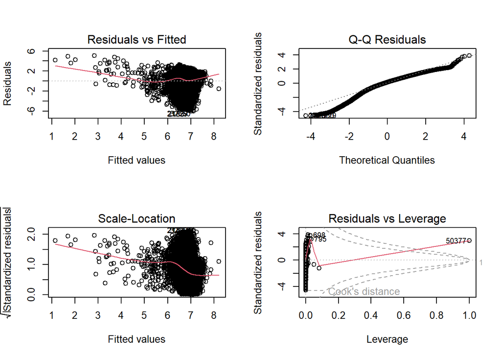

```r
par(mfrow = c(2,2))
plot(m3)
```

## Model 2

Model 2 introduces additional explanatory variables including show age and popularity. The results indicate that run-time remains statistically insignificant, suggesting that episode length does not meaningfully influence ratings. Show age is positively and significantly associated with ratings, indicating that older television shows tend to receive slightly higher ratings perhaps due to nostalgia. This result opposes expectation that more recent shows would be rated higher. Additionally, the number of IMDb votes (log-transformed) is strongly and positively associated with ratings, suggesting that more popular shows tend to receive higher audience ratings. The Model 2 fit improves substantially compared to Model 1, although the explanatory power remains modest.

## Model 3

Model 3 incorporates control variables for production scale, including the number of episodes and number of seasons. The results show that run-time remains statistically insignificant, meaning episode length does not meaningfully affect IMDb ratings. Show age remains positively and significantly associated with ratings, suggesting that older television shows tend to receive slightly higher ratings. The number of IMDb votes (log-transformed) continues to have a strong positive relationship with ratings, indicating that more popular shows tend to receive higher audience ratings. Among the control variables, the number of episodes is negatively associated with ratings, while the number of seasons is positively associated with ratings. This suggests that while longer-running shows may accumulate more episodes of varying quality, shows that are renewed for multiple seasons tend to maintain higher overall ratings.Model 3’s fit improves relative to previous models with a slight increase in the R-squared value.

## Model Selection

Model 3 is selected as the final model because it includes both the main explanatory variables and theoretically relevant control variables. It also demonstrates improved model fit compared to Models 1 and 2.

## Linearity

The Residuals vs Fitted plot shows a slight curvature in the residuals, suggesting that the linear model may not fully capture the relationship between the predictors and the response variable. The deviations are not extreme, but they may indicate some lack of model clarity.

## Normality

The Q-Q plot shows deviations from the diagonal line, particularly in the tails, indicating that the residuals are not perfectly normally distributed. Given the large sample size, this violation may not substantially affect the validity of the regression estimates.

## Homoskedasticity

The Scale-Location plot indicates that the spread of residuals is not constant across fitted values, suggesting the presence of heteroskedasticity. This means that the variance of the errors may differ depending on the predicted rating level.

## Overall Analysis and Limitations

This analysis identifies several factors associated with IMDb ratings for television shows. Popularity, measured through the number of IMDb votes, is strongly associated with higher ratings, while run-time does not appear to meaningfully affect audience evaluations. Older television shows also tend to receive slightly higher ratings, potentially reflecting survivorship bias or nostalgia effects among viewers.

Several limitations should be noted. IMDb ratings are user-generated and may not represent the preferences of all viewers. The data set also does not include variables such as production budget, streaming platform, marketing, or audience demographics which may influence television ratings. Future research could incorporate additional production-level variables or compare ratings across streaming services and traditional television networks. One key note that might be worth looking at as well is within genre comparison for specific TV shows or even episode comparison within different shows.